# US Sales Time Series Forecast

```r
library('fpp2')
```

We will be using real data i.e., deflated data so that we can isolate real growth. This will prevent inflation from distorting the picture for us.

```r
sales = read.csv('RSXFSN.csv')
cpi = read.csv('USACPIALLMINMEI.csv')
real = sales[,2]/cpi[,2]
data = ts(real,start=c(1992,1),frequency=12)
data
```

```
##           Jan      Feb      Mar      Apr      May      Jun      Jul      Aug
## 1992 2242.874 2244.377 2424.413 2500.572 2585.979 2567.104 2574.055 2564.897
## 1993 2277.424 2227.099 2525.733 2610.726 2687.710 2674.878 2701.567 2684.267
## 1994 2355.190 2364.224 2794.643 2746.358 2820.534 2858.761 2766.231 2902.186
## 1995 2491.659 2437.019 2847.805 2756.122 2963.008 2978.006 2842.790 2997.513
## 1996 2569.301 2661.522 2920.485 2909.804 3114.776 2977.339 2976.148 3077.906
## 1997 2697.510 2649.779 3018.263 2947.459 3131.348 3038.357 3084.263 3124.143
## 1998 2749.236 2690.297 3039.034 3095.982 3219.748 3211.609 3161.490 3141.926
## 1999 2839.155 2873.755 3307.177 3238.790 3386.434 3377.421 3369.594 3410.974
## 2000 3000.750 3169.816 3512.573 3307.598 3559.829 3506.669 3352.872 3531.759
## 2001 3069.864 3019.621 3409.157 3337.023 3583.372 3466.240 3358.351 3558.059
## 2002 3085.450 3040.483 3408.551 3392.546 3581.382 3430.554 3511.102 3642.690
## 2003 3160.283 3022.297 3403.832 3430.041 3635.750 3499.671 3600.016 3661.977
## 2004 3235.538 3229.248 3641.816 3584.567 3713.220 3619.151 3690.094 3678.867
## 2005 3274.601 3278.694 3756.762 3678.928 3795.344 3867.520 3843.787 3878.788
```

[output cut: 49 more lines]

Let’s start plotting the data to have look:

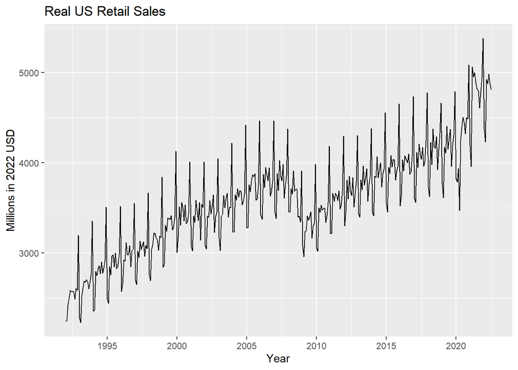

```r
autoplot(data)+ggtitle("Real US Retail Sales")+ylab("Millions in 2022 USD")+xlab('Year')
```

We have a strong positive trend in growth. We can see the dip which is probably explained by the 2008 recesion. It seems like there is some seasonality in the data. We will investigate that further.

But first let’s have a look at the stationary data by taking the first difference:

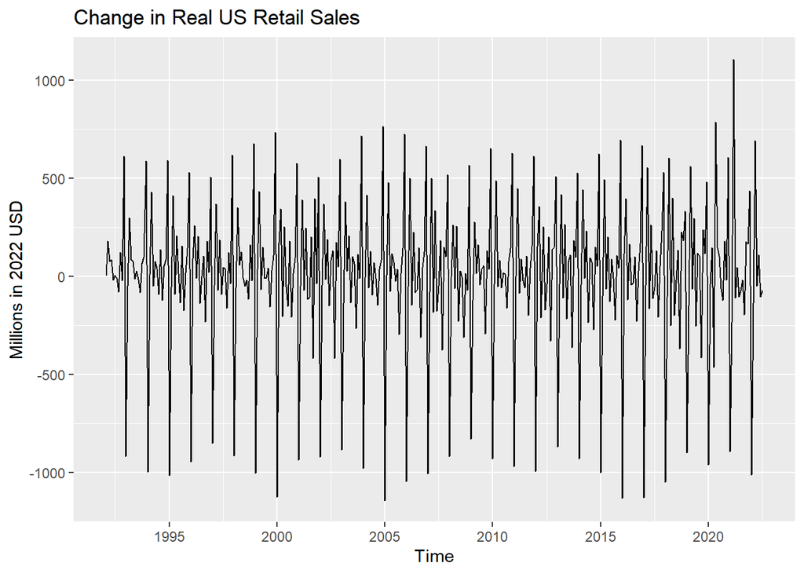

```r
diff  = diff(data)
autoplot(diff)+ggtitle("Change in Real US Retail Sales")+ylab("Millions in 2022 USD")
```

We see that the data is now trend stationary. Now we have got rid of the trend. We can see large fluctuations in the data. We need to check whether these fluctuations are regualar or irregualar. Let’s create a seasonal plot for the same.

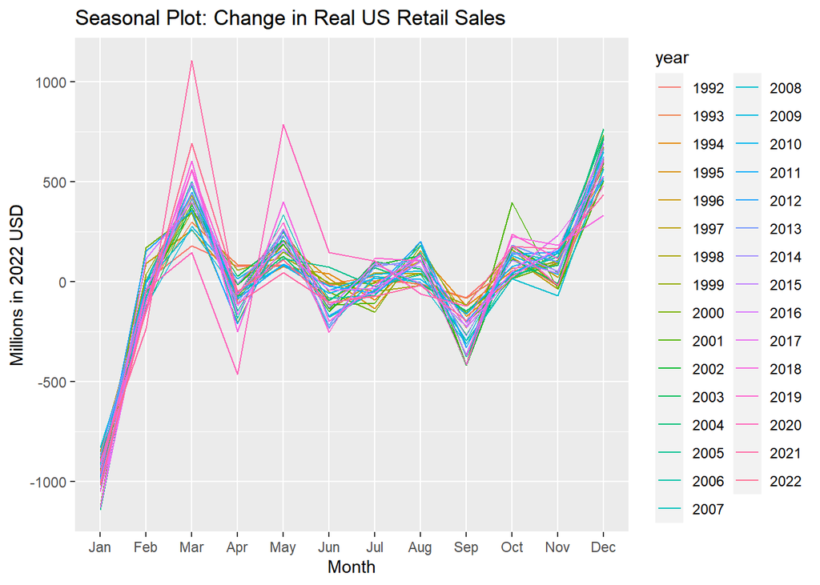

```r
ggseasonplot(diff)+ggtitle("Seasonal Plot: Change in Real US Retail Sales")+ylab("Millions in 2022 USD")
```

We can see strong seasonality in the data. There is consistent growth in November to December months succeded by a sharp fall in January and which it picks up again in February to March. This upsurge and fall can be attributed to Christman shopping. The next surge and fall can probably be explained by the upcoming summer, change in retail stock and Easter.

Let’s confirm our observationss with a subseries plot:

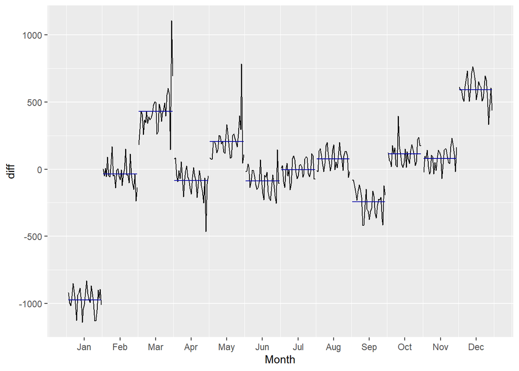

```r
ggsubseriesplot(diff)
```

This is enough for a preliminary analysis. We can now proceed with modeling and eventually making our projections based on the model of our choice.

Let’s start with the benchmark method, i.e., Naive methods. Since our data is seasonal we will go with seasonal naive, `snaive()` function which will use the corresponding season from last year as a benchmark. Mathematically, we can write this model as $y_t = y_{t-s} + \epsilon_{t}$ , where $t$ is time, $s$ is the duration going back for the benchmark, and $y_t$ is the sales in year $t$. Now because the data has a trend therefore that would imply compounding errors for the model hence it would be better to use the first difference data i.e., stationary data for this model.

We’ll fit the model, summarize it and check its residuals.

```r
fit_naive = snaive(diff)
summary(fit_naive)
```

```
##
## Forecast method: Seasonal naive method
##
## Model Information:
## Call: snaive(y = diff)
##
## Residual sd: 125.9141
##
## Error measures:
##                      ME     RMSE      MAE      MPE     MAPE MASE       ACF1
## Training set -0.1234631 125.9141 86.10822 -25.8476 163.9355    1 -0.2224476
##
## Forecasts:
##          Point Forecast        Lo 80      Hi 80       Lo 95      Hi 95
## Aug 2022      -18.79436  -180.159710  142.57099  -265.58137  227.99265
## Sep 2022     -194.29125  -355.656599  -32.92590  -441.07826   52.49576
## Oct 2022      175.41414    14.048790  336.77949   -71.37287  422.20115
## Nov 2022      163.80768     2.442328  325.17303   -82.97933  410.59469
## Dec 2022      436.80272   275.437369  598.16807   190.01571  683.58973
## Jan 2023    -1011.87677 -1173.242125 -850.51142 -1258.66378 -765.08977
## Feb 2023     -137.66373  -299.029081   23.70162  -384.45074  109.12328
## Mar 2023      691.79857   530.433223  853.16393   445.01157  938.58558
## Apr 2023      -49.05961  -210.424956  112.30575  -295.84661  197.72740
## May 2023      109.43095   -51.934404  270.79630  -137.35606  356.21795
## Jun 2023     -103.83776  -265.203111   57.52759  -350.62477  142.94925
## Jul 2023      -70.88651  -232.251857   90.47885  -317.67351  175.90050
## Aug 2023      -18.79436  -246.999427  209.41071  -367.80389  330.21518
## Sep 2023     -194.29125  -422.496316   33.91382  -543.30078  154.71829
## Oct 2023      175.41414   -52.790927  403.61921  -173.59539  524.42368
## Nov 2023      163.80768   -64.397389  392.01275  -185.20185  512.81721
## Dec 2023      436.80272   208.597652  665.00779    87.79319  785.81225
## Jan 2024    -1011.87677 -1240.081842 -783.67171 -1360.88631 -662.86724
## Feb 2024     -137.66373  -365.868798   90.54134  -486.67326  211.34580
## Mar 2024      691.79857   463.593506  920.00364   342.78904 1040.80811
## Apr 2024      -49.05961  -277.264673  179.14546  -398.06914  299.94993
## May 2024      109.43095  -118.774121  337.63601  -239.57859  458.44048
## Jun 2024     -103.83776  -332.042828  124.36731  -452.84729  245.17177
## Jul 2024      -70.88651  -299.091574  157.31856  -419.89604  278.12303
```

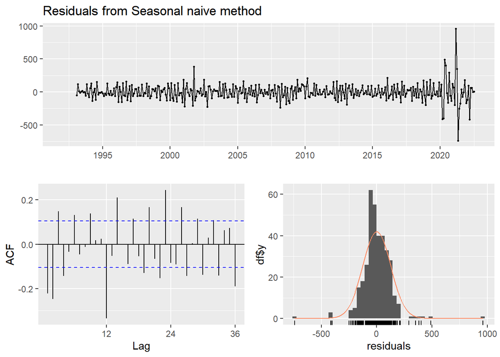

```
##
##  Ljung-Box test
##
## data:  Residuals from Seasonal naive method
## Q* = 190.42, df = 24, p-value < 2.2e-16
##
## Model df: 0.   Total lags used: 24
```

```r
checkresiduals(fit_naive)
```

We have a residual standard deviation of $125.9141$. This is our benchmark for other models that we may try. This tells us that the seasonal naive model fits the data relatively well and misses on average by about $126$ Million USD.

Cheching residuals we see that the data seems pretty random. However, looking at the ACF graph we see a lot of autocorrelation in the graph over the $95$ percent confidence intervals. This means that the model is failing to account for some information in the data. We will have to lower our auto correlation.

For our next model, we’ll try out the exponential smoothing model. These are a class of time dseries forecasting model. This model with try out every single possible exponential smoothing model and it will return the best fitter. This model will test for trend and include it in the fit. Therefore, we can use the real sales data for this one.

Let’s try it out:

```r
fit_ets = ets(data)
summary(fit_ets)
```

```
## ETS(M,A,M)
##
## Call:
##  ets(y = data)
##
##   Smoothing parameters:
##     alpha = 0.4086
##     beta  = 0.0021
##     gamma = 0.1567
##
##   Initial states:
##     l = 2492.5071
##     b = 10.393
##     s = 1.2121 1.007 0.9895 0.9632 1.0187 1.0036
##            1.0152 1.0282 0.9892 0.9943 0.8878 0.8911
##
##   sigma:  0.0247
##
##      AIC     AICc      BIC
## 5465.513 5467.266 5531.904
##
## Training set error measures:
##                     ME     RMSE      MAE        MPE     MAPE      MASE
## Training set -4.535841 93.22968 62.61398 -0.1638317 1.716813 0.4982476
##                    ACF1
## Training set 0.08720487
```

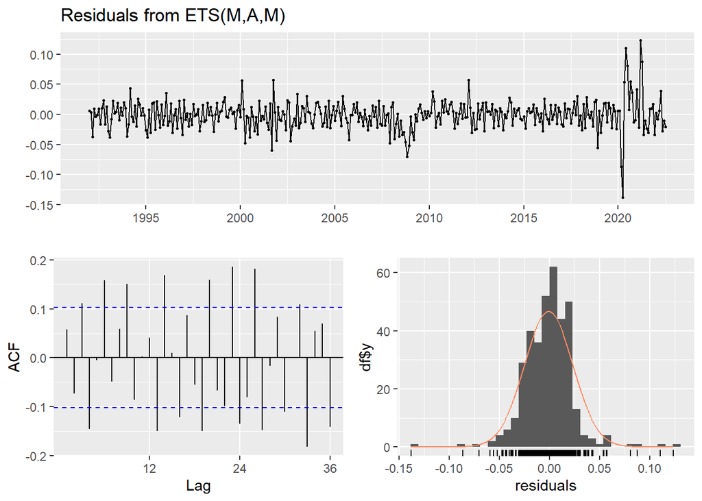

```
##
##  Ljung-Box test
##
## data:  Residuals from ETS(M,A,M)
## Q* = 113.7, df = 8, p-value < 2.2e-16
##
## Model df: 16.   Total lags used: 24
```

```r
checkresiduals(fit_ets)
```

The model picked by ETS is ETS(M,A,M) model i.e., the multiplicative, additive and multiplicative model. The first letter denotes the error type; the second letter denotes the trend type; and the third letter denotes the season type. So, the errors are being compounded and so is the seasonality.

This model can be described mathematically as: $y_{t}=(l_{t-1}+b_{t-1})s_{t-m}(1+\epsilon_{t})$ $l_{t}=(l_{t-1}+b_{t-1})s_{t-m}(1+\alpha\epsilon_{t})$ $b_{t}=(l_{t-1}+b_{t-1})s_{t-m}(1+\epsilon_{t})$ $s_{t}=s_{t-m}(1+\gamma\epsilon_{t})$ where, $\alpha, \beta, \gamma$ are the soothing parameters, and, $l_{0},b_{0},s_{0},s_{-1},..$ are the initial states.

The `auto.arima()` function uses a variation of the Hyndman Khandakar algoritm which combines unit root tests, minimisation of the AICs and MLE to obtain an ARIMA model. We need stationary data for the ARIMA model therefore, we wll tell the function to take the first difference of the data we provide by supplying the constant `d=1`, we will also take the first seasonal difference by supplying `D=1`. We don’t want it to approximate so we set the to `approximation=FALSE`, and setting `stepwise=FALSE` will force it to try all the models, while `trace=FALSE` implies it will not print out each model it tries but rather only the final selection.

Let’s try it out:

```r
fit_arima = auto.arima(data,d=1,D=1,stepwise=FALSE,approximation=FALSE, trace=FALSE)
summary(fit_arima)
```

```
## Series: data
## ARIMA(4,1,0)(0,1,1)[12]
##
## Coefficients:
##           ar1      ar2      ar3      ar4     sma1
##       -0.4088  -0.3656  -0.0386  -0.2042  -0.8091
## s.e.   0.0530   0.0569   0.0574   0.0527   0.0365
##
## sigma^2 = 8341:  log likelihood = -2104.57
## AIC=4221.14   AICc=4221.38   BIC=4244.35
##
## Training set error measures:
##                    ME     RMSE      MAE         MPE     MAPE      MASE
## Training set 1.365128 89.06185 60.60952 -0.01337592 1.649582 0.4822972
##                     ACF1
## Training set -0.02179607
```

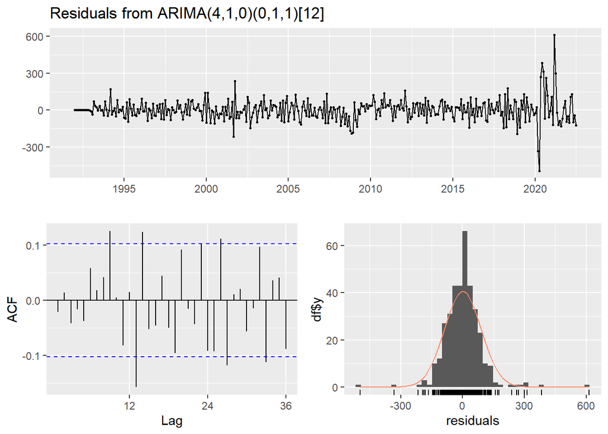

```
##
##  Ljung-Box test
##
## data:  Residuals from ARIMA(4,1,0)(0,1,1)[12]
## Q* = 46.393, df = 19, p-value = 0.0004359
##
## Model df: 5.   Total lags used: 24
```

```r
checkresiduals(fit_arima)
```

$ARIMA(p,d,q)(P,D,Q)_{S}$, where $(p,d,q)$ is the non seasonal part and $(P,D,Q)$ is the seasonal part of the model, and $S$ is the number of observations per year. Mathematically, $ARIMA(p,d,q)(P,D,Q)_{S}$ can be written as:
$$\Phi(B^{S})\phi(B)(x_{t}-\mu)=\Theta(B^{S})\theta(B)w_{t}$$
The non seasonal parts are: AR: $\phi(B)=1-\phi_{1}B-...-\phi_{p}B^{p}$ MA: $\theta(B)=1+\theta_{1}B+...+\theta_{q}B^{q}$

The seasonal parts are: Seasonal AR: $\Phi(B)=1-\Phi_{1}B^{S}-...-\Phi_{P}B^{PS}$ Seasonal MA: $\Theta(B)=1+\Theta_{1}B^{S}+...+\Theta_{Q}B^{QS}$

We can see quite easily here that the autocorrelation is almost within the $95$ percent confidence intervals. This is what we were looking for. Now we can proceed with forecasting the data.

We will forecast using both the ETS and ARIMA models. First, with ARIMA:

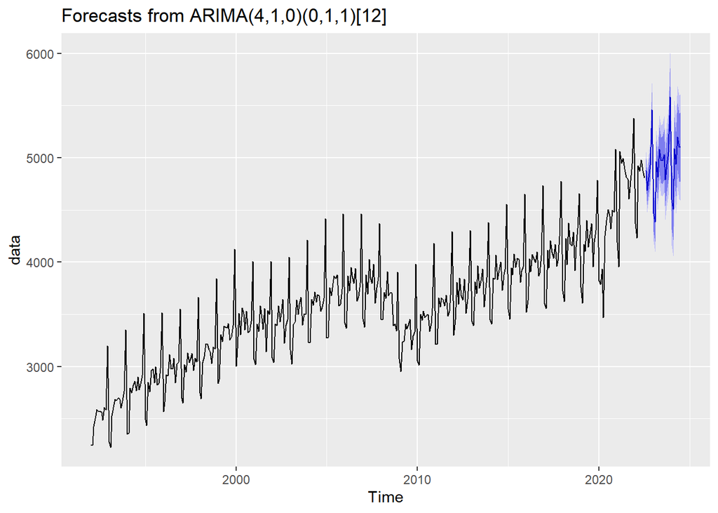

```r
forecast1 = forecast(fit_arima, h=24)
autoplot(forecast1)
```

And let’s look at the zoomed in plot for the same.

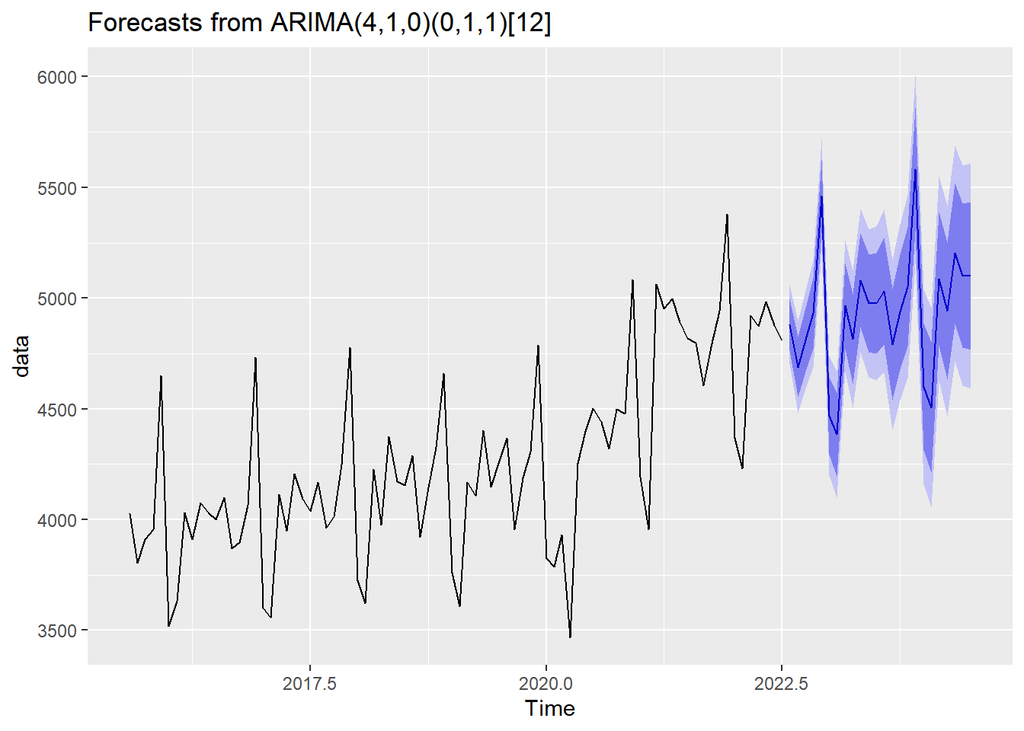

```r
autoplot(forecast1, include = 84)
```

Now with ETS:

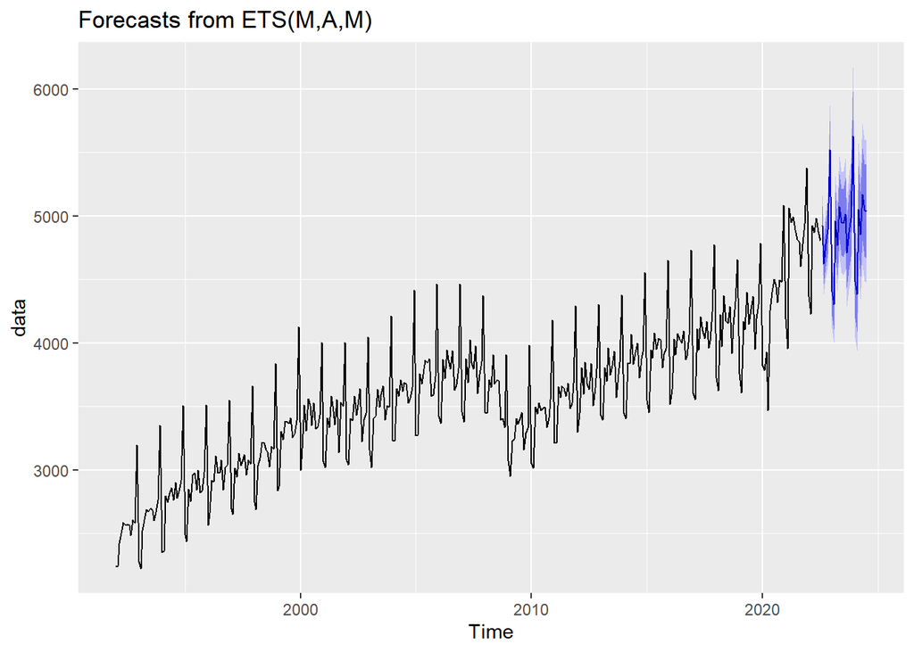

```r
forecast2 = forecast(fit_ets, h=24)
autoplot(forecast2)
```

And let’s look at the zoomed in plot for the same.

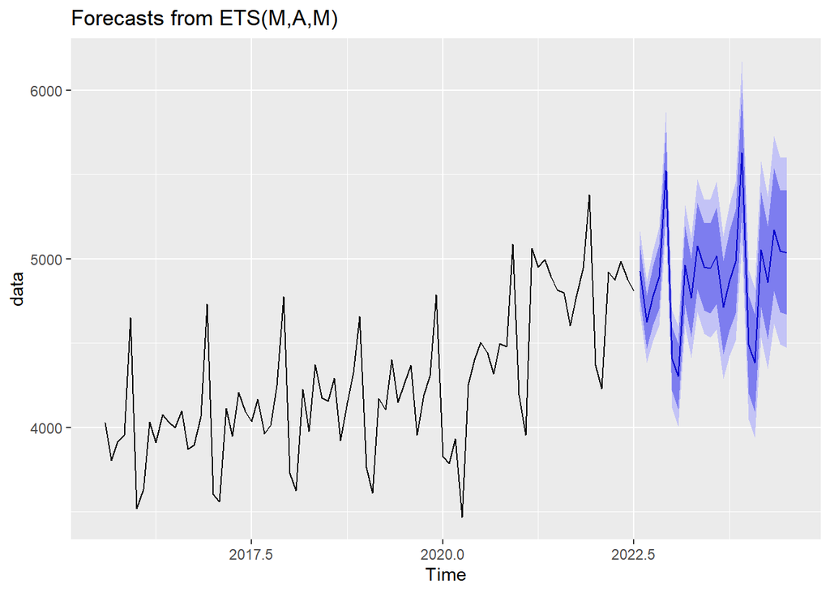

```r
autoplot(forecast2, include = 84)
```

Next we can look at the summary of each forecast to conclude.

```r
summary(forecast1)
```

```
##
## Forecast method: ARIMA(4,1,0)(0,1,1)[12]
##
## Model Information:
## Series: data
## ARIMA(4,1,0)(0,1,1)[12]
##
## Coefficients:
##           ar1      ar2      ar3      ar4     sma1
##       -0.4088  -0.3656  -0.0386  -0.2042  -0.8091
## s.e.   0.0530   0.0569   0.0574   0.0527   0.0365
##
## sigma^2 = 8341:  log likelihood = -2104.57
## AIC=4221.14   AICc=4221.38   BIC=4244.35
##
## Error measures:
##                    ME     RMSE      MAE         MPE     MAPE      MASE
## Training set 1.365128 89.06185 60.60952 -0.01337592 1.649582 0.4822972
##                     ACF1
## Training set -0.02179607
##
## Forecasts:
##          Point Forecast    Lo 80    Hi 80    Lo 95    Hi 95
## Aug 2022       4879.388 4762.344 4996.432 4700.385 5058.391
## Sep 2022       4688.219 4552.249 4824.190 4480.271 4896.168
## Oct 2022       4811.463 4667.934 4954.992 4591.955 5030.972
## Nov 2022       4930.879 4771.871 5089.886 4687.698 5174.059
## Dec 2022       5462.812 5297.370 5628.254 5209.790 5715.834
## Jan 2023       4468.563 4293.433 4643.693 4200.725 4736.401
## Feb 2023       4384.288 4197.544 4571.032 4098.688 4669.888
## Mar 2023       4965.498 4771.158 5159.838 4668.280 5262.716
## Apr 2023       4815.443 4612.111 5018.775 4504.474 5126.412
## May 2023       5080.344 4868.710 5291.978 4756.678 5404.010
## Jun 2023       4976.529 4757.645 5195.414 4641.774 5311.285
## Jul 2023       4976.219 4749.405 5203.033 4629.337 5323.101
## Aug 2023       5033.439 4792.869 5274.010 4665.519 5401.360
## Sep 2023       4790.544 4539.790 5041.297 4407.049 5174.038
## Oct 2023       4937.407 4677.739 5197.075 4540.279 5334.535
## Nov 2023       5052.221 4783.095 5321.346 4640.629 5463.813
## Dec 2023       5582.307 5305.036 5859.578 5158.257 6006.357
## Jan 2024       4600.145 4314.365 4885.924 4163.083 5037.207
## Feb 2024       4506.959 4212.684 4801.235 4056.904 4957.015
## Mar 2024       5088.403 4786.290 5390.517 4626.360 5550.446
## Apr 2024       4941.421 4631.421 5251.421 4467.317 5415.525
## May 2024       5202.857 4885.239 5520.475 4717.102 5688.611
## Jun 2024       5101.146 4776.173 5426.118 4604.143 5598.148
## Jul 2024       5101.075 4768.783 5433.368 4592.878 5609.273
```

```r
summary(forecast2)
```

```
##
## Forecast method: ETS(M,A,M)
##
## Model Information:
## ETS(M,A,M)
##
## Call:
##  ets(y = data)
##
##   Smoothing parameters:
##     alpha = 0.4086
##     beta  = 0.0021
##     gamma = 0.1567
##
##   Initial states:
##     l = 2492.5071
##     b = 10.393
##     s = 1.2121 1.007 0.9895 0.9632 1.0187 1.0036
##            1.0152 1.0282 0.9892 0.9943 0.8878 0.8911
##
##   sigma:  0.0247
##
##      AIC     AICc      BIC
## 5465.513 5467.266 5531.904
##
## Error measures:
##                     ME     RMSE      MAE        MPE     MAPE      MASE
## Training set -4.535841 93.22968 62.61398 -0.1638317 1.716813 0.4982476
##                    ACF1
## Training set 0.08720487
##
## Forecasts:
##          Point Forecast    Lo 80    Hi 80    Lo 95    Hi 95
## Aug 2022       4924.497 4768.661 5080.333 4686.166 5162.828
## Sep 2022       4624.798 4466.612 4782.984 4382.873 4866.723
## Oct 2022       4780.428 4605.460 4955.396 4512.838 5048.018
## Nov 2022       4893.122 4702.946 5083.297 4602.274 5183.970
## Dec 2022       5524.087 5297.485 5750.689 5177.529 5870.645
## Jan 2023       4405.996 4216.177 4595.816 4115.692 4696.300
## Feb 2023       4302.160 4108.293 4496.027 4005.666 4598.655
## Mar 2023       4961.199 4728.157 5194.242 4604.791 5317.607
## Apr 2023       4768.679 4535.867 5001.491 4412.624 5124.734
## May 2023       5076.724 4819.771 5333.676 4683.749 5469.698
## Jun 2023       4952.790 4693.478 5212.103 4556.206 5349.375
## Jul 2023       4943.870 4676.628 5211.111 4535.159 5352.580
## Aug 2023       5017.896 4731.286 5304.507 4579.564 5456.229
## Sep 2023       4712.375 4435.762 4988.989 4289.332 5135.419
## Oct 2023       4870.810 4577.345 5164.276 4421.994 5319.627
## Nov 2023       4985.490 4677.530 5293.450 4514.505 5456.475
## Dec 2023       5628.203 5272.129 5984.277 5083.634 6172.771
## Jan 2024       4488.909 4198.316 4779.503 4044.485 4933.333
## Feb 2024       4382.993 4092.916 4673.069 3939.359 4826.627
## Mar 2024       5054.269 4712.566 5395.973 4531.678 5576.861
## Apr 2024       4857.998 4522.742 5193.255 4345.268 5370.729
## May 2024       5171.666 4807.599 5535.732 4614.874 5728.457
## Jun 2024       5045.271 4683.206 5407.337 4491.540 5599.003
## Jul 2024       5036.041 4667.839 5404.243 4472.925 5599.157
```

References: [1] Sales data RSXFSN taken from: [FRED ECONOMIC DATA](https://fred.stlouisfed.org/series/RSXFSN/) [2] CPI Data USACPIALLMINMEI taken from: [FRED ECONOMIC DATA](https://fred.stlouisfed.org/series/USACPIALLMINMEI)